# Biostat M280 Homework 2

   geom_histogram():
   - Pros: the value of y at each point of x is more obvious. The skewness is obvious.
   - Cons: it is hard to compare all the categories since they are not in the same plot.

   geom_freqpoly():
   - Pros: it is easy to compare all the categories since they are in the same plot. The visual difference in the overall shape, skewness, etc of the distribution is obvious.
   - Cons: the precise value of y at a category is not obvious.

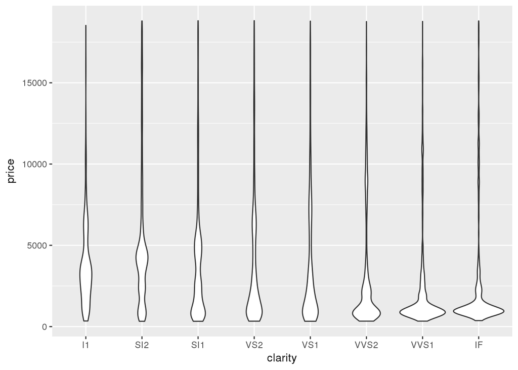

   ```r
   ggplot(diamonds, aes(x = clarity, y = price)) +
     geom_violin()
   ```

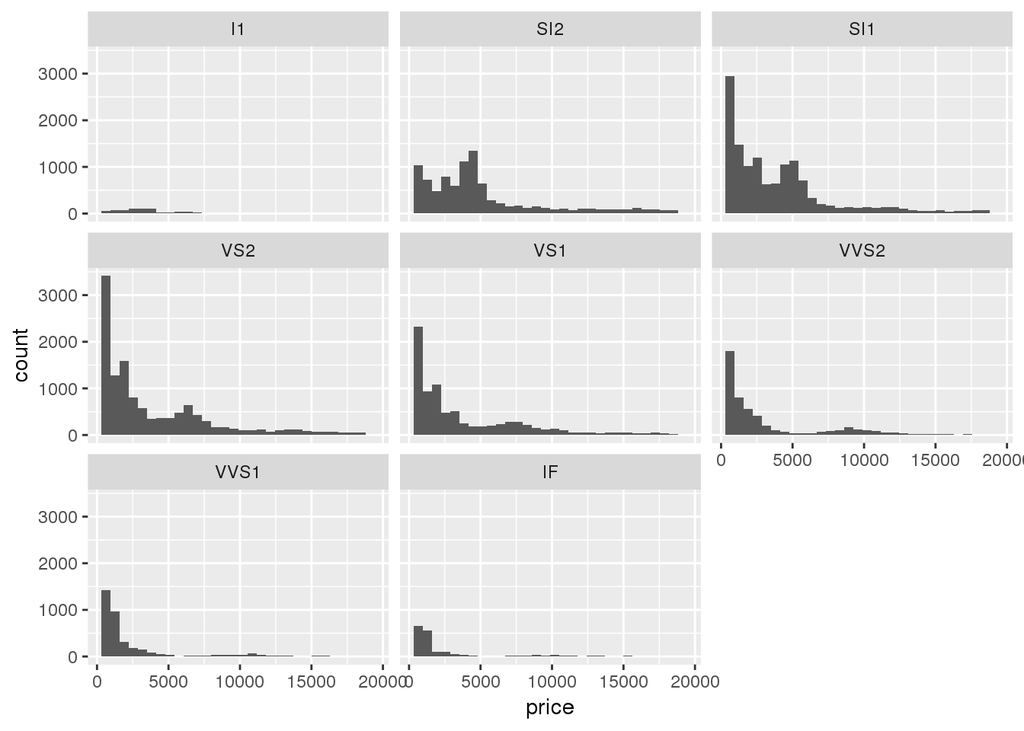

   ```r
   ggplot(diamonds) +
     geom_histogram(aes(x = price)) +
     facet_wrap(~clarity)
   ```

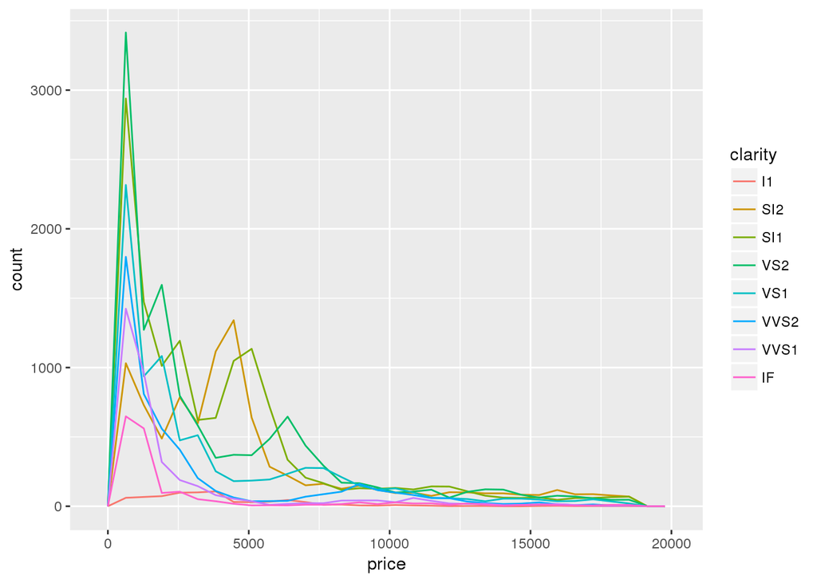

   ```r
   ggplot(diamonds) +
     geom_freqpoly(aes(x = price, color = clarity))
   ```

   Reference: http://varianceexplained.org/RData/code/code_lesson2/
6. If you have a small dataset, it’s sometimes useful to use geom_jitter() to see the relationship between a continuous and categorical variable. The ggbeeswarm package provides a number of methods similar to geom_jitter(). List them and briefly describe what each one does.

   The plots created by geom_quasirandom looks like a combination of those created by geom_jitter() and geom_violin(). It not only shows the density but also the width and length and the overall shape of the distribution.

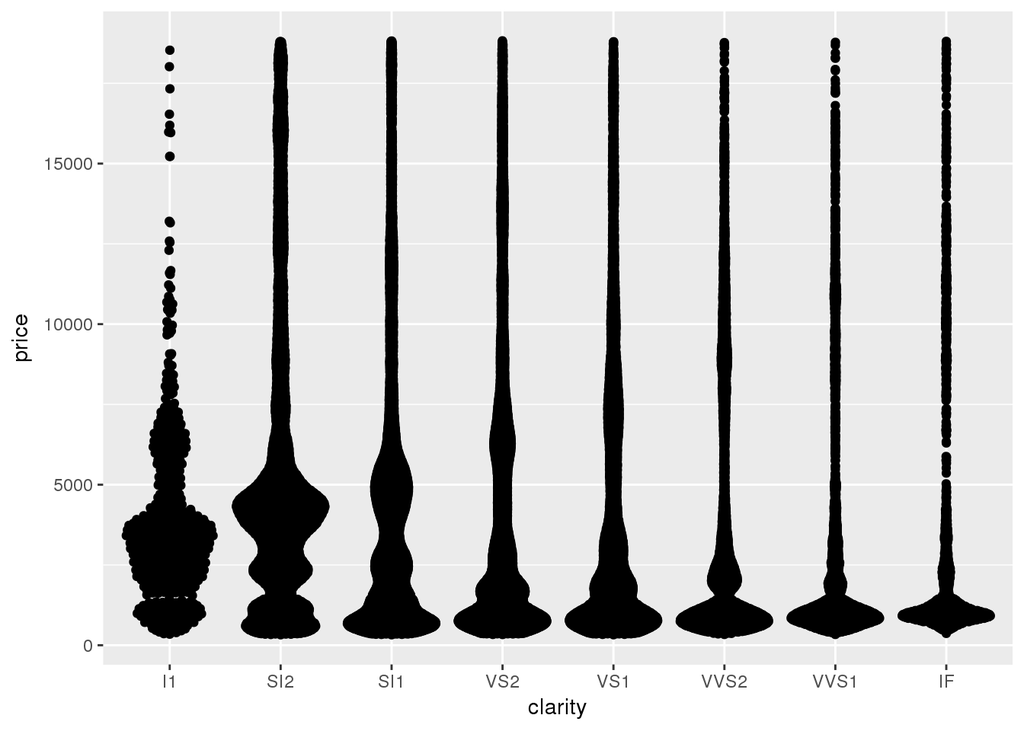

   ```r
   ggplot(diamonds, aes(x = clarity, y = price)) +
     geom_quasirandom()
   ```

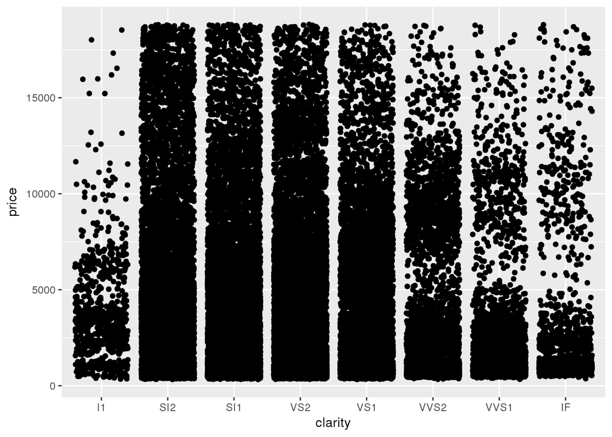

   ```r
   ggplot(diamonds, aes(x = clarity, y = price)) +
     geom_jitter()
   ```

7.5.2.1

1. How could you rescale the count dataset above to more clearly show the distribution of cut within colour, or colour within cut?

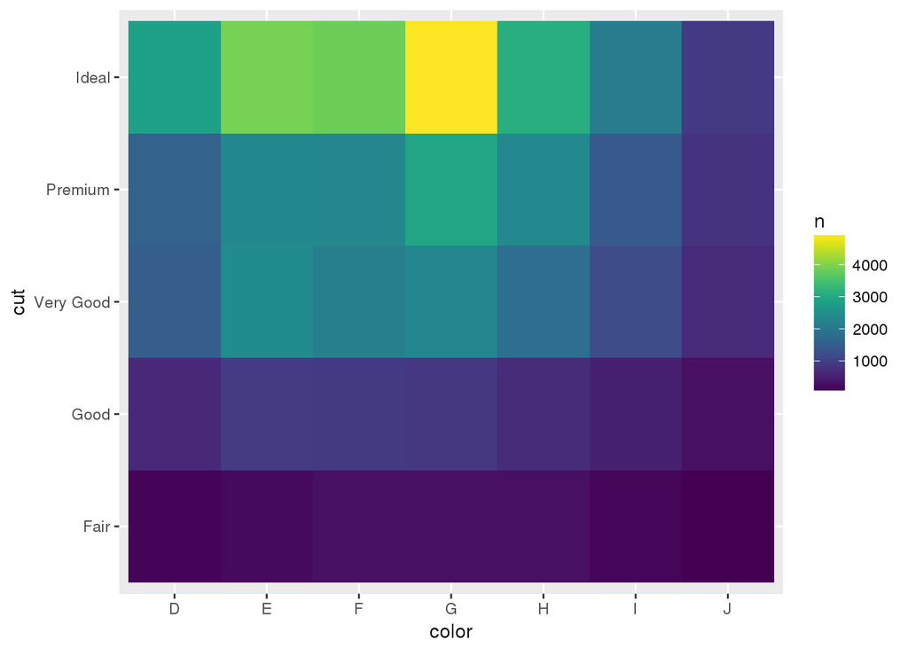

   ```r
   diaplot <- diamonds %>%
     count(color, cut) %>%
     group_by(color) %>%
     mutate(perc = n / sum(n)) %>%
     ggplot(aes(color, cut, fill = n)) +
     geom_tile() +
     scale_fill_viridis()
   diaplot
   ```

2. Use geom_tile() together with dplyr to explore how average flight delays vary by destination and month of year. What makes the plot difficult to read? How could you improve it?